# Prediction Assignment Writeup

Jordi Carrère Molina

11 de February, 2017

# Background

Using devices such as Jawbone Up, Nike FuelBand, and Fitbit it is now possible to collect a large amount of data about personal activity relatively inexpensively. These type of devices are part of the quantified self movement – a group of enthusiasts who take measurements about themselves regularly to improve their health, to find patterns in their behavior, or because they are tech geeks. One thing that people regularly do is quantify how much of a particular activity they do, but they rarely quantify how well they do it. In this project, your goal will be to use data from accelerometers on the belt, forearm, arm, and dumbell of 6 participants. They were asked to perform barbell lifts correctly and incorrectly in 5 different ways. More information is available from the website here: http://groupware.les.inf.puc-rio.br/har (see the section on the Weight Lifting Exercise Dataset). Data

The training data for this project are available here: https://d396qusza40orc.cloudfront.net/predmachlearn/pml-training.csv

The test data are available here: https://d396qusza40orc.cloudfront.net/predmachlearn/pml-testing.csv

The data for this project come from this source: http://groupware.les.inf.puc-rio.br/har. If you use the document you create for this class for any purpose please cite them as they have been very generous in allowing their data to be used for this kind of assignment.

# Loading and cleaning data

## Importing data

Data was downloaded from the above URLs and the two .csv files werw loaded to R objects, `train` and `test`

```r
workingDir <- getwd()

dataDir <- paste(workingDir,"/data", sep='')
if(!(dir.exists(dataDir))){
        dir.create(dataDir)
}

url1 <- "https://d396qusza40orc.cloudfront.net/predmachlearn/pml-training.csv"
destfile1 <- paste(dataDir,"/pml-training.csv", sep='')
if(!(file.exists("data/pml-training.csv"))){
        download.file(url1, destfile1)
}

url2 <- "https://d396qusza40orc.cloudfront.net/predmachlearn/pml-testing.csv"
destfile2 <- paste(dataDir,"/pml-testing.csv", sep='')
if(!(file.exists("data/pml-testing.csv"))){
        download.file(url2, destfile2)
}

training <- read.csv("data/pml-training.csv", row.names = 1, na.strings=c("NA", "#DIV/0!"))
testing <- read.csv("data/pml-testing.csv", row.names = 1, na.strings=c("NA", "#DIV/0!"))
```

## Exploring data

A simple view of the data shows that there’s a lot of variables full of NAs. Data was cleaned in the next step to reduce dimensionality.

```r
str(training, list.len=15, vec.len=2)
```

```
'data.frame':   19622 obs. of  159 variables:
 $ user_name               : Factor w/ 6 levels "adelmo","carlitos",..: 2 2 2 2 2 ...
 $ raw_timestamp_part_1    : int  1323084231 1323084231 1323084231 1323084232 1323084232 ...
 $ raw_timestamp_part_2    : int  788290 808298 820366 120339 196328 ...
 $ cvtd_timestamp          : Factor w/ 20 levels "02/12/2011 13:32",..: 9 9 9 9 9 ...
 $ new_window              : Factor w/ 2 levels "no","yes": 1 1 1 1 1 ...
 $ num_window              : int  11 11 11 12 12 ...
 $ roll_belt               : num  1.41 1.41 1.42 1.48 1.48 ...
 $ pitch_belt              : num  8.07 8.07 8.07 8.05 8.07 ...
 $ yaw_belt                : num  -94.4 -94.4 -94.4 -94.4 -94.4 ...
 $ total_accel_belt        : int  3 3 3 3 3 ...
 $ kurtosis_roll_belt      : num  NA NA NA NA NA ...
 $ kurtosis_picth_belt     : num  NA NA NA NA NA ...
 $ kurtosis_yaw_belt       : logi  NA NA NA ...
 $ skewness_roll_belt      : num  NA NA NA NA NA ...
 $ skewness_roll_belt.1    : num  NA NA NA NA NA ...
  [list output truncated]
```

## Cleaning data

```r
dim(training)
```

```
[1] 19622   159
```

```r
train_cl <- training[, apply(training, 2, function(x) !any(is.na(x)))]
train_cl <- train_cl[,-c(1:7)]
dim(train_cl)
```

```
[1] 19622    52
```

```r
set.seed(12345)
inTrain <- createDataPartition(y=train_cl$classe, p=0.75, list=F)
train <- train_cl[inTrain,]
test <- train_cl[-inTrain,]
dim(train)
```

```
[1] 14718    52
```

```r
dim(test)
```

```
[1] 4904   52
```

The `testing` set was cleaned too, and renamed, since this set wasn’t used for testing, but predict new data.

```r
vars <- names(train_cl)
newdata <- testing[,names(testing) %in% vars]
dim(newdata)
```

```
[1] 20 51
```

# Trainning model: Random Forest

Random Forests generate several decision trees from a selected number of randomly chosen characters so that the trees do not contain all the variables of our data, but each variable is present in several trees in the forest. After generating the set of trees (forest), the model uses the vote of each tree to predict a new example. The parameters of the function `rf` allow to modify are:

```r
require(caret)
```

```r
modelLookup("rf")
```

```
  model parameter                         label forReg forClass probModel
1    rf      mtry #Randomly Selected Predictors   TRUE     TRUE      TRUE
```

Model was trained using a 3-fold crossvalidation and using 5 values of `mtry`.

```r
set.seed(12345)
trControl <- trainControl(method="cv", number=3, verboseIter=FALSE)
rf_model <- train(classe ~ ., data=train_cl, method="rf", tuneLength = 5,
                          trControl=trControl)
```

```r
rf_model
```

```
Random Forest

19622 samples
   51 predictors
    5 classes: 'A', 'B', 'C', 'D', 'E'

No pre-processing
Resampling: Cross-Validated (3 fold)
Summary of sample sizes: 13081, 13081, 13082
Resampling results across tuning parameters:

  mtry  Accuracy   Kappa
   2    0.9922536  0.9902008
  14    0.9943940  0.9929088
  26    0.9929670  0.9911031
  38    0.9910814  0.9887173
  51    0.9886352  0.9856217

Accuracy was used to select the optimal model using  the largest value.
The final value used for the model was mtry = 14.
```

In the next grafic we can see the accuracy of the models by `mtry` value.

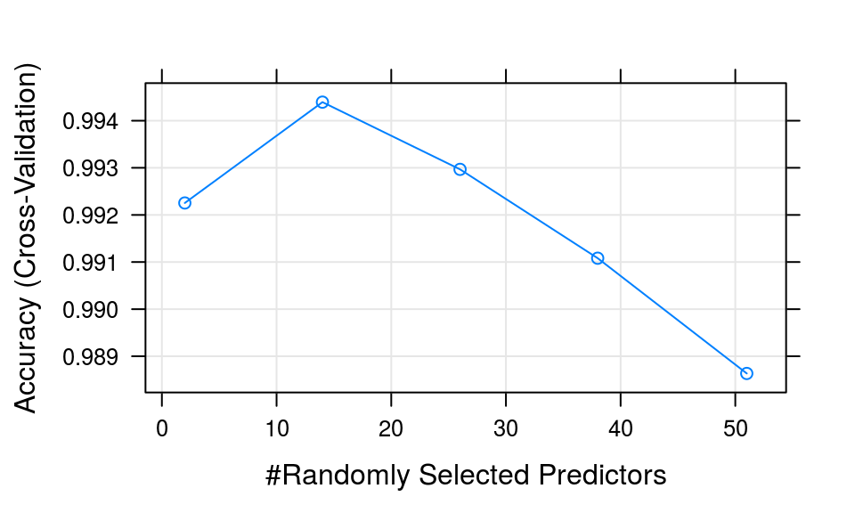

```r
plot(rf_model)
```

```r
set.seed(12345)
pred <- predict(rf_model, test)
(confMat_rf <- confusionMatrix(pred, test$classe))
```

```
Confusion Matrix and Statistics

          Reference
Prediction    A    B    C    D    E
         A 1395    0    0    0    0
         B    0  949    0    0    0
         C    0    0  855    0    0
         D    0    0    0  804    0
         E    0    0    0    0  901

Overall Statistics

               Accuracy : 1
                 95% CI : (0.9992, 1)
    No Information Rate : 0.2845
    P-Value [Acc > NIR] : < 2.2e-16

                  Kappa : 1
 Mcnemar's Test P-Value : NA

Statistics by Class:

                     Class: A Class: B Class: C Class: D Class: E
Sensitivity            1.0000   1.0000   1.0000   1.0000   1.0000
Specificity            1.0000   1.0000   1.0000   1.0000   1.0000
Pos Pred Value         1.0000   1.0000   1.0000   1.0000   1.0000
Neg Pred Value         1.0000   1.0000   1.0000   1.0000   1.0000
Prevalence             0.2845   0.1935   0.1743   0.1639   0.1837
Detection Rate         0.2845   0.1935   0.1743   0.1639   0.1837
Detection Prevalence   0.2845   0.1935   0.1743   0.1639   0.1837
Balanced Accuracy      1.0000   1.0000   1.0000   1.0000   1.0000
```

# Predictions

```r
preds <- predict(rf_model, newdata=newdata)
preds
```

```
 [1] B A B A A E D B A A B C B A E E A B B B
Levels: A B C D E
```

This predictions were used to answer *Course Project Prediction Quiz*.